# Group4-KKT,KYJ,KYR,SJH

# 3-29 Los Angeles

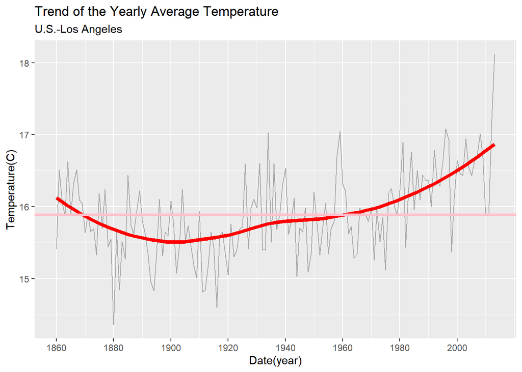

```r
# KIM KYU TAE
# Los Angeles

city9 <- yclean %>% filter(City==part3_cities[6]) %>% na.omit()
city9 %>% group_by(year) %>% summarise(ave = mean(AverageTemperature)) %>% na.omit() %>%
  ggplot() + geom_line(col="dark grey") + aes(x=year, y=ave) + geom_smooth(col='Red', se=F, lwd=1.7)+
  geom_hline(yintercept=mean(city9$AverageTemperature), col='pink', lwd=1.3)+
  labs(title = "Trend of the Yearly Average Temperature", subtitle="U.S.-Los Angeles", x= "Date(year)", y="Temperature(C)")+
  scale_x_continuous(breaks = seq(1860, 2013, 20))
```

[figure not shown]

```r
city %>% group_by(season, year) %>% summarise(ave = mean(AverageTemperature)) %>% na.omit() %>%
  ggplot() + geom_line(col="dark grey") + aes(x=year, y=ave) + geom_smooth(col='light blue', se=F)+
  labs(title = "Trend of the Yearly Average Temperature by Season", subtitle="Los Angeles", x= "Date(year)", y="Temperature(C)")+
  scale_x_continuous(breaks = seq(1860, 2013, 20))+
  facet_wrap(~season)
```

The population at the time of the U.S. Navy’s occupation of Korea in 1846 was less than 1,000. However, from the end of the 19th century, urban development began steadily based on the development of agriculture. With oil spilling in 1891, the development of large-scale oil fields began in the 20th century, the opening of the Panama Canal and the development of shipping due to the port of San Pedro Bay in 1914, the development of the film industry centered on Hollywood, the increase of tourism and recreation tourists due to the expansion of transportation routes, the development of related processing industries, and the development of machinery, chemicals, aviation and automobile industries. After World War II, the decline of agriculture is marked by rapid industrialization. It was easy to obtain industrial materials centered on oil, and the industry developed greatly after World War II by using the water resources of Hoover Dam, which was completed in 1936. Railways, highways, and airways are concentrated throughout the country, making it the center of the southern part of the Pacific Coast for land and air traffic. (Coast-Pacific)